# Discriminant analysis

Revanth

2024-04-25

```r
library(MASS)
library(ggplot2)
library(memisc)
library(ROCR)
library(dplyr)
library(car)
library(klaR)
library(ROCR)
library(caret)
library(titanic)
# Load the dataset and inspect the structure
data("titanic_train")
titanic_data <- titanic_train
str(titanic_data)
```

```
## 'data.frame':    891 obs. of  12 variables:
##  $ PassengerId: int  1 2 3 4 5 6 7 8 9 10 ...
##  $ Survived   : int  0 1 1 1 0 0 0 0 1 1 ...
##  $ Pclass     : int  3 1 3 1 3 3 1 3 3 2 ...
##  $ Name       : chr  "Braund, Mr. Owen Harris" "Cumings, Mrs. John Bradley (Florence Briggs Thayer)" "Heikkinen, Miss. Laina" "Futrelle, Mrs. Jacques Heath (Lily May Peel)" ...
##  $ Sex        : chr  "male" "female" "female" "female" ...
##  $ Age        : num  22 38 26 35 35 NA 54 2 27 14 ...
##  $ SibSp      : int  1 1 0 1 0 0 0 3 0 1 ...
##  $ Parch      : int  0 0 0 0 0 0 0 1 2 0 ...
##  $ Ticket     : chr  "A/5 21171" "PC 17599" "STON/O2. 3101282" "113803" ...
##  $ Fare       : num  7.25 71.28 7.92 53.1 8.05 ...
##  $ Cabin      : chr  "" "C85" "" "C123" ...
##  $ Embarked   : chr  "S" "C" "S" "S" ...
```

```r
# Keep relevant columns and remove missing values
titanic_data <- titanic_data[, c("Survived", "Pclass", "Sex", "Age", "Fare")]
titanic_data <- na.omit(titanic_data)

# Convert categorical variables to numeric
titanic_data$Sex <- as.numeric(factor(titanic_data$Sex))
```

# Model Development

```r
library(MASS)

# Fit an LDA model
lda_model <- lda(Survived ~ ., data = titanic_data)
print(lda_model)
```

```
## Call:
## lda(Survived ~ ., data = titanic_data)
##
## Prior probabilities of groups:
##         0         1
## 0.5938375 0.4061625
##
## Group means:
##     Pclass      Sex      Age     Fare
## 0 2.485849 1.849057 30.62618 22.96546
## 1 1.872414 1.320690 28.34369 51.84321
##
## Coefficients of linear discriminants:
##                  LD1
## Pclass -0.8354196738
## Sex    -1.9952663200
## Age    -0.0226161162
## Fare    0.0002834735
```

## Insights

### Prior Probabilities of groups:

#### These probabilities represent the overall likelihood of each class (Survived vs. Not Survived) in the dataset

#### 1. Not Survived (0): Approximately 59.38%

#### 2. Survived (1): Approximately 40.62%

### Group Means

#### The group means show the average values of each predictor variable for each class

#### 1. Pclass (Passenger class): The average passenger class is higher (closer to 3, which indicates lower socio-economic status) for those who did not survive (2.49) compared to those who survived (1.87). This suggests that lower-class passengers had a lower survival rate, which is historically accurate.

### Coefficients of Linear Discriminants

#### 3. Age: The small negative coefficient (-0.023) suggests a slight trend where older individuals are more likely to not survive, although this effect is minimal.

#### 4. Fare: The very small positive coefficient (0.000283) indicates that higher fares slightly increase the likelihood of survival, aligning with the group means.

## key findings

### 1. Social Class and Fare: There’s a strong socio-economic factor in survival, with higher-class passengers who paid higher fares having better survival chances.

### 2. Gender Bias in Survival: Gender plays a significant role, with females having a higher likelihood of survival.

### 3. Age: Age has a minimal effect, but younger passengers had a slightly better chance of survival.

# Model Acceptance

```r
summary(lda_model)
```

```
##         Length Class  Mode
## prior   2      -none- numeric
## counts  2      -none- numeric
## means   8      -none- numeric
## scaling 4      -none- numeric
## lev     2      -none- character
## svd     1      -none- numeric
## N       1      -none- numeric
## call    3      -none- call
## terms   3      terms  call
## xlevels 0      -none- list
```

```r
print(lda_model)
```

```
## Call:
## lda(Survived ~ ., data = titanic_data)
##
## Prior probabilities of groups:
##         0         1
## 0.5938375 0.4061625
##
## Group means:
##     Pclass      Sex      Age     Fare
## 0 2.485849 1.849057 30.62618 22.96546
## 1 1.872414 1.320690 28.34369 51.84321
##
## Coefficients of linear discriminants:
##                  LD1
## Pclass -0.8354196738
## Sex    -1.9952663200
## Age    -0.0226161162
## Fare    0.0002834735
```

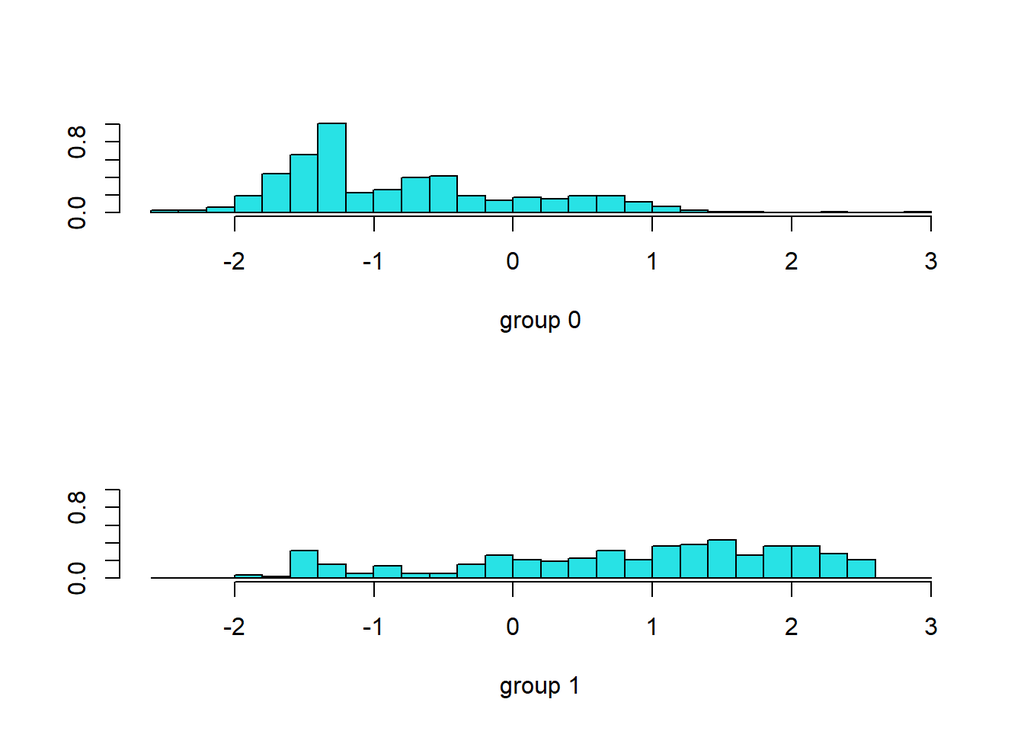

```r
plot(lda_model)
```

# Residual Analysis

```r
lda_pred <- predict(lda_model, titanic_data)

# Create a confusion matrix to see the correct and incorrect predictions
conf_matrix <- table(Predicted = lda_pred$class, Actual = titanic_data$Survived)
print(conf_matrix)
```

```
##          Actual
## Predicted   0   1
##         0 360  87
##         1  64 203
```

```r
# Examining the posterior probabilities
head(lda_pred$posterior)
```

```
##            0          1
## 1 0.92963258 0.07036742
## 2 0.05610043 0.94389957
## 3 0.37345045 0.62654955
## 4 0.05093878 0.94906122
## 5 0.95516527 0.04483473
## 7 0.73496828 0.26503172
```

### The posterior probabilities from LDA give the probability that a given observation belongs to each possible class,

### Each row in lda_pred$posterior represents an observation, and each column represents a class.

```r
# Identify observations with high uncertainty
uncertain_predictions <- which(abs(lda_pred$posterior[,1] - 0.5) < 0.1)
titanic_data[uncertain_predictions, ]
```

```
##     Survived Pclass Sex  Age     Fare
## 19         0      3   1 31.0  18.0000
## 24         1      1   2 28.0  35.5000
## 26         1      3   1 38.0  31.3875
## 28         0      1   2 19.0 263.0000
## 35         0      1   2 28.0  82.1708
## 41         0      3   1 40.0   9.4750
## 80         1      3   1 30.0  12.4750
## 84         0      1   2 28.0  47.1000
## 86         1      3   1 33.0  15.8500
## 98         1      1   2 23.0  63.3583
## 103        0      1   2 21.0  77.2875
## 119        0      1   2 24.0 247.5208
## 133        0      3   1 47.0  14.5000
## 138        0      1   2 37.0  53.1000
```

[output cut: 53 more lines]

## Insights

### The residual analysis aims to assess the accuracy of the Linear Discriminant Analysis (LDA) model by examining the discrepancies between the predicted class probabilities and the actual class labels.

# Model Prediction

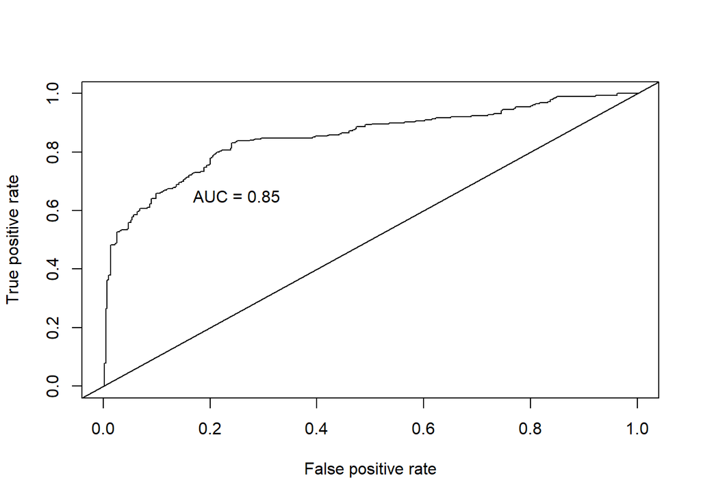

```r
titanic.lda <- lda(Survived ~ Pclass + Sex + Age + Fare, data = titanic_data, na.action = na.omit)

titanic_pred <- predict(titanic.lda, titanic_data)
titanic_pred_posterior <- titanic_pred$posterior[,2]  # Assuming 'Survived' is coded as 1

titanic_data$Survived <- as.numeric(as.factor(titanic_data$Survived)) - 1

pred <- prediction(titanic_pred_posterior, titanic_data$Survived)

roc.perf <- performance(pred, measure = "tpr", x.measure = "fpr")
auc.train <- performance(pred, measure = "auc")
auc.train <- auc.train@y.values[[1]]  # Extract AUC value

# Plot ROC curve
plot(roc.perf)
abline(a=0, b=1)
text(x = .25, y = .65 ,paste("AUC = ", round(auc.train, 3), sep = ""))
```

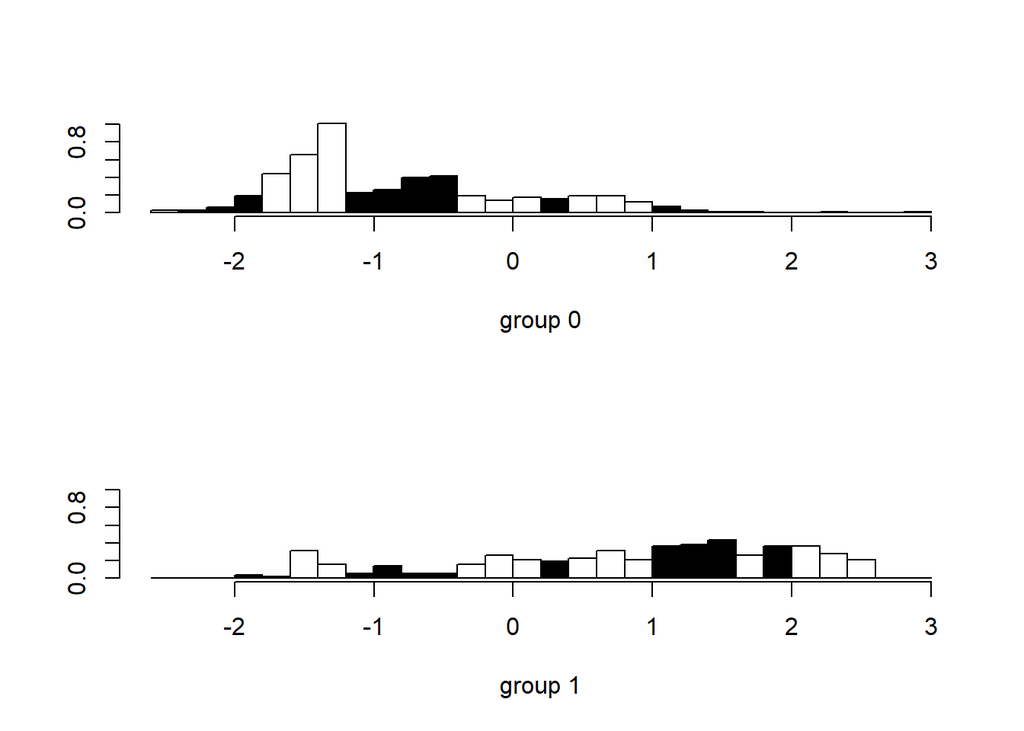

```r
# Fit LDA model
titanic_lda <- lda(Survived ~ Pclass + Sex + Age + Fare, data = titanic_data)

# Plot the LDA
plot(titanic_lda, col = as.integer(titanic_data$Survived))
```

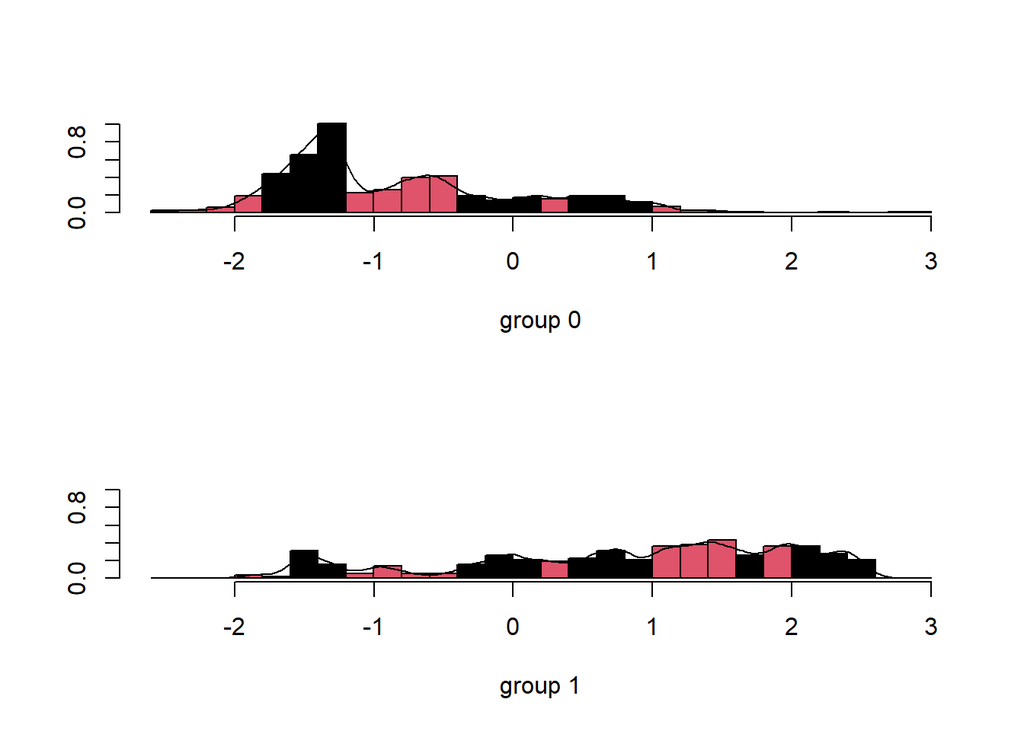

```r
# Fit LDA model
titanic_lda <- lda(Survived ~ Pclass + Sex + Age + Fare, data = titanic_data)

# Plot the first discriminant
plot(titanic_lda, dimen = 1, type = "b", col = as.integer(titanic_data$Survived + 1))  # Adding 1 for color differentiation
```

### Good Separation: Indicates that the features used are effective predictors of survival.

### Poor Separation: Suggests that the model may struggle to predict survival based solely on these features, or that the relationships between features and survival are not linear.

```r
titanic_data$Pclass <- as.factor(titanic_data$Pclass)  # Make sure Pclass is a factor
titanic_data$Age <- ifelse(is.na(titanic_data$Age), median(titanic_data$Age, na.rm = TRUE), titanic_data$Age)
titanic_data$Fare <- ifelse(is.na(titanic_data$Fare), median(titanic_data$Fare, na.rm = TRUE), titanic_data$Fare)

# MANOVA
m_titanic <- manova(cbind(Age, Fare) ~ Pclass, data = titanic_data)
summary(m_titanic, test = "Wilks")
```

```
##            Df   Wilks approx F num Df den Df    Pr(>F)
## Pclass      2 0.54017   128.02      4   1420 < 2.2e-16 ***
## Residuals 711
## ---
## Signif. codes:  0 '***' 0.001 '**' 0.01 '*' 0.05 '.' 0.1 ' ' 1
```

```r
summary(m_titanic, test = "Pillai")
```

```
##            Df  Pillai approx F num Df den Df    Pr(>F)
## Pclass      2 0.46309   107.12      4   1422 < 2.2e-16 ***
## Residuals 711
## ---
## Signif. codes:  0 '***' 0.001 '**' 0.01 '*' 0.05 '.' 0.1 ' ' 1
```

```r
# ANOVA for each dependent variable
summary.aov(m_titanic)
```

```
##  Response Age :
##              Df Sum Sq Mean Sq F value    Pr(>F)
## Pclass        2  20930 10464.8  57.444 < 2.2e-16 ***
## Residuals   711 129527   182.2
## ---
## Signif. codes:  0 '***' 0.001 '**' 0.01 '*' 0.05 '.' 0.1 ' ' 1
##
##  Response Fare :
##              Df  Sum Sq Mean Sq F value    Pr(>F)
## Pclass        2  721567  360784  201.17 < 2.2e-16 ***
## Residuals   711 1275127    1793
## ---
## Signif. codes:  0 '***' 0.001 '**' 0.01 '*' 0.05 '.' 0.1 ' ' 1
```

## Insights

### Wilks’ Test:

#### The Wilks’ Lambda test assesses the significance of the relationship between the predictors and the response variable.

#### The results indicate a statistically significant relationship between the predictor variables and the response variable, as evidenced by the small p-value (2.2e-16), suggesting rejection of the null hypothesis.

### Pillai’s Test:

#### Pillai’s trace is another measure of the relationship between the predictors and the response variable.

#### Similar to Wilks’ test, Pillai’s trace yields a small p-value (2.2e-16), indicating a significant relationship between the predictor variables and the response variable.

# Model Accuracy

```r
titanic_data$Survived <- factor(titanic_data$Survived)
titanic_data$Pclass <- factor(titanic_data$Pclass)
titanic_data$Sex <- as.numeric(factor(titanic_data$Sex))  # Converting 'Sex' to numeric
titanic_data$Age <- ifelse(is.na(titanic_data$Age), median(titanic_data$Age, na.rm = TRUE), titanic_data$Age)
titanic_data$Fare <- ifelse(is.na(titanic_data$Fare), median(titanic_data$Fare, na.rm = TRUE), titanic_data$Fare)
```

```r
# Splitting data into training and test sets
set.seed(123)
training_indices <- createDataPartition(titanic_data$Survived, p = 0.8, list = FALSE)
train_titanic <- titanic_data[training_indices, ]
test_titanic <- titanic_data[-training_indices, ]
```

```r
# Fitting LDA model on the training set
titanic_lda <- lda(Survived ~ Pclass + Sex + Age + Fare, data = train_titanic)
```

```r
# Prediction on the training set
titanic_lda_predict_train <- predict(titanic_lda, newdata = train_titanic)
train_class <- titanic_lda_predict_train$class
train_table <- table(Predicted = train_class, Actual = train_titanic$Survived)
print(train_table)
```

```
##          Actual
## Predicted   0   1
##         0 279  69
##         1  61 163
```

### Confusion Matrix

#### TP: 163 passengers were correctly predicted as survived.

```r
# Running accuracy on the training set
train_accuracy <- sum(diag(train_table)) / sum(train_table)
print(paste("Training Set Accuracy:", train_accuracy))
```

```
## [1] "Training Set Accuracy: 0.772727272727273"
```

### Accuracy: The accuracy on the training set is approximately 77.27%. This indicates that the LDA model correctly predicts the survival status of about 77.27% of the passengers in the training set

```r
# Prediction on the test set
titanic_lda_predict_test <- predict(titanic_lda, newdata = test_titanic)
test_class <- titanic_lda_predict_test$class
test_table <- table(Predicted = test_class, Actual = test_titanic$Survived)
print(test_table)
```

```
##          Actual
## Predicted  0  1
##         0 74 19
##         1 10 39
```

```r
# Running accuracy on the test set
test_accuracy <- sum(diag(test_table)) / sum(test_table)
print(paste("Test Set Accuracy:", test_accuracy))
```

```
## [1] "Test Set Accuracy: 0.795774647887324"
```

### Confusion Matrix

#### TP: 39 passengers were correctly predicted as survived.

### Accuracy: The accuracy on the test set is approximately 79.58%. This suggests that the model is slightly more effective when predicting new, unseen data compared to the training data.

## Final Conclusions:

### The model shows a decent performance with accuracies of 77.27% for the training set and 79.58% for the test set. The higher accuracy in the test set suggests that the model generalizes well, though it’s also possible that the test set may have been slightly easier for the model due to its composition.

### There is a bias towards predicting non-survivors more accurately than survivors, as evidenced by the higher number of true negatives (TN) compared to true positives (TP) in both sets.